# SNACS

## Overview

SNACS is an R package for demultiplexing hashes which have simultaneous profiles of single-cell genetic mutations and cell surface antibodies.

## Loading SNACS package (this section will be modified)

The relevant packages needed to run SNACS can be loaded with the following code

```r
library(VIM)
source("../src/processData.R")
source("../src/getBestSNPs.R")
source("../src/hashCall.R")
source("../src/createHeatmap.R")
```

## Loading example data

The first step in using the SNACS package is to properly format the data. The mutation data should be a numeric matrix with SNPs in the rows and cells in the columns. 1s represent mutations and 0s non-mutations. The antibody data should be a matrix with hashes in the rows and cells in the columns. The hash antibody value should be a continuous numeric measure. An example data file has been included with the package. It has 750 cells from three hashes and 24 SNPs.

```r
load("example.RData")
```

Matrix “mutMat” has the mutation data.

```r
dim(mutMat)
```

```
## [1]  24 750
```

```r
mutMat[1:4,1:4]
```

```
##         cell1 cell2 cell3 cell4
## snp986      0     1     0     1
## snp3007     1     0     0     1
## snp3340     1     0     1     0
## snp3446     1     0     1     0
```

Matrix “hashMat” has the has antibody data.

```r
dim(hashMat)
```

```
## [1]   3 750
```

```r
hashMat[,1:4]
```

```
##              cell1        cell2     cell3      cell4
## CD45.26 -0.4956392 -1.393167400 -1.711933  1.1746812
## CD45.27 -1.3285484  1.400040600 -0.670479 -0.5418549
## CD45.28  1.8241878 -0.006873033  2.382412 -0.6328267
```

## Create SNACSList object

SNACS stores data in a simple list-based data object called a SNACSList. The SNACSList object can be made for the example data by

```r
## Parameters mut, hashes, exptName are mandatory while hashColors is optional
exptName <- "snacsExpt"
hashColors <- c("green3","indianred2","dodgerblue3")

snacsObj <- SNACSList(mut=mutMat,hashes=hashMat,exptName=exptName,hashColors=hashColors)
snacsObj
```

```
## An object of class "SNACSList"
## Experiment name: snacsExpt
## No. of SNPs: 24
## No. of cells: 750
## Hashes: CD45.26, CD45.27, CD45.28
## SNACSList attributes: mut, hashes, exptName, annHash, annCell, annSNP
## Output files are saved in "../output" folder
```

```r
snacsObj$mut[1:4,1:4]
```

```
##      cell1 cell2 cell3 cell4
## snp1     0     1     0     1
## snp2     1     0     0     1
## snp3     1     0     1     0
## snp4     1     0     1     0
```

```r
snacsObj$hashes[,1:4]
```

```
##              cell1        cell2     cell3      cell4
## CD45.26 -0.4956392 -1.393167400 -1.711933  1.1746812
## CD45.27 -1.3285484  1.400040600 -0.670479 -0.5418549
## CD45.28  1.8241878 -0.006873033  2.382412 -0.6328267
```

```r
snacsObj$annHash
```

```
##   hashNames  hashColors
## 1   CD45.26      green3
## 2   CD45.27  indianred2
## 3   CD45.28 dodgerblue3
```

```r
snacsObj$annCell[1:4,]
```

```
##      id  desc
## 1 cell1 cell1
## 2 cell2 cell2
## 3 cell3 cell3
## 4 cell4 cell4
```

```r
snacsObj$annSNP[1:4,]
```

```
##     id desc
## 1 snp1 snp1
## 2 snp2 snp2
## 3 snp3 snp3
## 4 snp4 snp4
```

## Impute missing mutations

SNACS functions cannot work on mutation data with missing values. The missing mutations can be imputed by

```r
snacsObj <- imputeMissingMutations(snacsObj=snacsObj)
snacsObj
```

```
## An object of class "SNACSList"
## Experiment name: snacsExpt
## No. of SNPs: 23
## No. of cells: 750
## Hashes: CD45.26, CD45.27, CD45.28
## SNACSList attributes: mut, hashes, exptName, annHash, annCell, annSNP, missing
## Output files are saved in "../output" folder
```

## Cluster mutation data to select best SNPs to demultiplex hashes

The cells are clustered based on mutation data. The clustering takes place in two steps. First, mutation data is clustered based on all SNPs. An intermediate heatmap is generated identifying three cell clusters representing the three hashes and the SNPs ranked by how well they separate the three cell clusters. Then a second round of clustering is performed to select SNPs which best separate the cell clusters from the first round. The heatmaps are saved in “../output” folder.

```r
## The p-value for selecting best SNPs can be specified
pvSnpThres <- 0.05

snacsObj <- getBestSNPs(snacsObj,pvSnpThres=pvSnpThres)
snacsObj
```

```
## An object of class "SNACSList"
## Experiment name: snacsExpt
## No. of SNPs: 18
## No. of cells: 750
## Hashes: CD45.26, CD45.27, CD45.28
## SNACSList attributes: mut, hashes, exptName, annHash, annCell, annSNP, missing, hclustObj_bestSNPs
## Output files are saved in "../output" folder
```

## Generate density plots of hash antibody data

```r
generateHashDensityPlot(snacsObj)
```

[output not shown]

## Make hash calls

This is the final step for demultiplexing the hashes. The cluster information from the mutation data and the hash antibody data are used to make hash calls. Each cell is assigned one of the three hash IDs or called a “Doublet” when it is a mixture of hashes.

```r
snacsObj=makeHashCall(snacsObj)
```

```
## "hashCall" column added to "annCell" table in SNACS object
##
##           Cell clusters with best SNPs
## Hash calls   1   2   3
##    CD45.26   0   0  69
##    CD45.27   0 396   0
##    CD45.28 240   0   0
##    Doublet  29   0  16
```

```r
## The hash calls are saved in the "annCell" table in the SNACSList object
snacsObj$annCell[1:4,]
```

[output not shown]

## Create heatmap

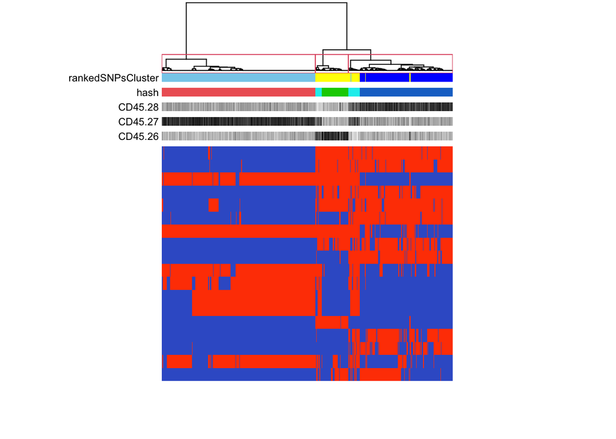

```r
## Heatmap of the mutation data with custom cell and SNP annotations
createHeatmap(snacsObj,
   cell_anno_var=c(snacsObj$annHash$hashNames,"hashCall","clustRankedSNPs_hclust"),
   cell_anno_name=c(snacsObj$annHash$hashNames,"hash","rankedSNPsCluster"),
   outFormat="")
```

```r
## The parameter "outFormat" can be used to save the heatmap in pdf format. The output is saved in "../output" folder
createHeatmap(snacsObj,
   cell_anno_var=c(snacsObj$annHash$hashNames,"hashCall","clustRankedSNPs_hclust"),
   cell_anno_name=c(snacsObj$annHash$hashNames,"hash","rankedSNPsCluster"),
   outputfileName=paste0("heatmap_pvBestWithAnn_",snacsObj$exptName),outFormat="pdf")
```